# AI4Stat/Math — interactive lit-review

edition v0.6 · 2026-06-11

**AI4Stat/Math** — a private benchmark of statistics/math problems that frontier LLMs fail, built at Rutgers/Stanford/UNC. This page is the project's literature-review & dedup working surface for collaborators. Unlisted working copy — please don't redistribute the link.

**Submissions:** 16 filled + 2 drafted of 375 scaffold slots · 3 of 25 contributors active — counts from the last Overleaf sync · submission deadline **June 15, 2026**

- **v0.6** · 2026-06-11  
  Per-problem review pages now lead with INFORMATION not verdicts (verdict pills + radar retired): how-the-frontier-models-do matrix, trajectory/failure-mode analysis, and oracle-vs-consensus disambiguation. Dedup rebuilt on current submissions via BM25 recall + method-judge (surface cosine relabeled as recall-only). Auto-rebuilds after every Overleaf Sync.
- **v0.5** · 2026-05-28  
  All dedup signals swapped to the best embedding: UMAP / cross-benchmark NN / max-cosine table use OpenAI text-embedding-3-large; the portal does in-browser semantic NN via bge-small (no draft text ever leaves the page). Lit-review HTML auto-rebuilds after every Overleaf Sync.
- **v0.4** · 2026-05-27  
  Portal auto-syncs from the contributor branch (submission progress digest); LLM-judge audit on the cross-benchmark nearest-neighbour pairs.
- **v0.3** · 2026-05-27  
  Three-column layout (table-of-contents · main · sources rail), readable section grouping, compact intro.
- **v0.2** · 2026-05-18  
  Interactive dedup portal (paste a candidate problem, or drop a .tex submission), citations rail with hover-sync, jargon tooltips.
- **v0.1** · 2026-05-11  
  First edition: 5 benchmarks ingested, deep report, 11 figures.

Interactive charts require JavaScript — static figures are embedded below.

§ Background

## Sources & citations

All works cited on this page, grouped. Link-pill icons: **📄** paper · **🗄** dataset · **‹›** code · **🔗** project site. On wide screens, the sticky rail on the right mirrors this list as you scroll; hovering any underlined name in the body lights up its entry both here and in the rail.

## The landscape

Each Tier-A precedent, side-by-side. Start with the table; expand the plot below to see authorship-vs-size at a glance.

### Sizes side-by-side

| Benchmark | Released | Paper claim | Latest claim | Ingested | Public? |
| --- | --- | --- | --- | --- | --- |

**Plot:** how big is each benchmark? (author count × problem count — click to expand)**

## Per-benchmark deep dive

Click any benchmark row below to expand its native taxonomy (verbatim — no coerced cross-walk), 3–5 concrete sample stems, and the one-line "do not duplicate" rule. Mathematical notation in stems renders fully when online. Tip: click a point in the landscape plot above to jump straight to its row here.

§ Deduplication Methodology

## Contributor dedup-checklist (interactive)

The same §A–§F flow as `research/dedup-checklist.md`, as tickable items. A candidate is rejected at Stage 1 if it fails §§A–C, or if §§D–E flag it without a documented sidecar justification. §F is the positive novelty gate. State is local to this page — nothing is saved.

## Submission audit + dedup portal

Two things in one section. **(1)** A live *screener*: paste a candidate problem statement and we flag matches against the **Tier-A pool** (the 5 publicly-downloadable precedent benchmarks: StatEval, MathTrap, StatQA, HARDMath, PRBench) *before* your draft reaches Stage-1 review. **(2)** A live *audit*: every contributor submission already in the bank, its SAME / PARAPHRASE / ADJACENT match type, and the specific precedent it matched (cosine + judge reason). Both run entirely in your browser; nothing leaves the page; results cache locally and can be cleared with the *Clear cache* button.

### Input

Drop `.tex` submission files here, or click to choose. Statement auto-extracted; you can edit it above before running.

### Limits

Heuristic screen — the deterministic §A–§F rules + a **semantic** nearest-neighbour over `bge-small-en-v1.5` embeddings of the ~5,300-stem Tier-A pool. The encoder runs entirely in your browser (loaded once on first use, ~30 MB; cached thereafter); your draft text never leaves the page. If the encoder fails to load (offline / blocked CDN), the portal falls back to a lexical wording-based NN. **Not a substitute for Stage-1 review.**

### Output

No run yet — paste a problem statement (or drop a .tex), then click *Run dedup check*. You'll get one match type per precedent (information, not a decision — the cosine score and matched precedent are shown so you can judge fit yourself): **SAME** (near-identical to an existing item) · **PARAPHRASE** (the same problem, reworded) · **ADJACENT** (related but distinct — shares structure or topic) · **UNRELATED** (no meaningful overlap) · **TEMPLATE** (a generic placeholder/skeleton, not a real stem).

Context (other contributors' work + match types the live audit has already computed):

### Submission progress (updates when contributors push new drafts)

Loading…

Per-contributor LLM-drafted reviews live on a sibling site → auto-review hub · agent audit · taxonomy

## Cross-benchmark UMAP

**How to read:** every dot is one problem stem. Its 2-D position comes from running UMAP on each stem's sentence-encoder embedding (OpenAI `text-embedding-3-large`, 3072 dimensions), so dots that sit together carry *similar meaning* — not merely similar vocabulary. The axes themselves are unit-less; only relative position matters. Colour = source benchmark. A tight same-colour clump = a benchmark with a consistent house style; colours that overlap = benchmarks that pose problems in adjacent territory (a dedup signal). Hover (desktop) or tap (touch) a dot to read its stem in the panel on the right.

### Selected stem

Hover or tap a point on the map.

—

### Cross-benchmark max cosine (sampled pairs)

| A → B | max cos |
| --- | --- |

## Cross-benchmark nearest-neighbour browser

### Per-pair browser

§ Project values

## Decisions only the co-PIs can make

Three calls; each unblocks downstream tooling. Tracked in Issue #14 (private repo). Two are *operational* (binary or default+override); one is *strategic* (open-framed, multiple paths).

### 1 · Embedding model operational · default + override

**Default:** `BAAI/bge-small-en-v1.5` (free, local, stems never leave the Space). **Override:** OpenAI `text-embedding-3-large` (~$0.03 build, candidates sent to OpenAI). Method audit — bge-small and TF-IDF surface the same noise (all top NN pairs UNRELATED); OpenAI's signal is qualitatively cleaner (max cos 0.52 vs 0.82) and surfaces the only adjacent pair. Production NN-search differences are material; cluster-topology now uses OpenAI on the headline UMAP.

### 2 · HF dataset visibility operational · binary

**Private** `yulinl-statsupai/ai4statmath-dedup-pool` (recommended — keeps candidate stems out of public scrape) vs **public** (faster onboarding, exposes candidates).

### 3 · Stance on StatEval superset strategic · three-option

(a) Coordinate a private overlap check with the StatEval team at submission; (b) accept source-leak rule as best-effort + document risk in the paper; or (c) constrain scope to StatEval-thin areas (decision theory, robust stats, advanced causal).

## Topical overlap atlas

The dedup portal and the UMAP/NN sections detect *collisions* at the problem level. This atlas zooms out: it shows *topic-level* coverage — where precedent benchmarks cluster, where they don't. Two views of the same cross-benchmark space.

**How to read:** each **row** is a slice of AI4Stat/Math's intended scope; each **column** is a precedent benchmark. **Dark blue** = that benchmark *directly* covers that scope (high collision risk); **mid blue** = adjacent/partial; **near-white** = untouched. A near-white row is open whitespace AI4Stat/Math can own. Hover any cell for the exact relationship.

## Whitespace ranking — where to push contributors

Blank-cell count per overlap-atlas row (max 9). Rows with 7+ blanks are the high-leverage contribution lanes; the recruitment-email cycle should steer here.

[output not shown]

§ Appendix

## Glossary

Every technical term is dotted-underlined at first use in each section, so you rarely need this list. Collapsed by default — search to filter, or expand to browse.

**Show all glossary terms** (or type a query above)**

## TL;DR — the headlines

One paragraph each. Drill into the per-benchmark accordion for the evidence.

1

### StatEval ships ~84k stems the paper never mentioned

arXiv v1: **16,191**. GitHub V1 README: **22,262 + 84,179 = 106,441** — i.e. **106,441 ÷ 16,191 ≈ 6.6× the paper**, of which 84,179 are the post-paper addition. HuggingFace ships only a 600-problem demo. Contributors cannot embed-search the unreleased 84k+ — the source-leak rule (76 textbooks + 18 stat journals 2000–2025) is the only realistic mechanism.

2

### PRBench's 6-bucket rubric is the precedent to differentiate against on methodology grounds

1,650 rows × 19,356 weighted criteria, six severity buckets in [-10,10]. LLM-judge κ=0.603 > expert-expert κ=0.589. PRBench's 6-bucket scheme fits their adversarial-debate use-case; our evaluation question (correctness + grading-mode robustness for stats/math problems) is different — pick a bucket count/scheme that matches it, even if the surface form ends up looking similar.

3

### MathTrap public sample skews toward Indirect Contradiction

104 ingested triplets: **46% Indirect Contradiction** [95% CI ≈ 37–56%, Wilson] vs paper-claimed 38% on the full private set. The 38% sits inside the 104-triplet CI, so the gap is within sampling noise — don't lean on it for category-level conclusions. "Violating Common Sense" (most stat-relevant) is under-represented by ~10 pts in the public sample → embed-NN against the public 104 will under-sample the most useful category; manual category citation required.

4

### StatQA's largest category is Descriptive Stats, not Correlation

Descriptive 23.1% > Contingency 21.5% > Distribution 20.6% > Variance 20.1% > Correlation 14.7% (smallest). Descriptive-stat problems over Kaggle tables carry higher StatQA-collision risk than the paper framing implies.

5

Decision theory w/ adversary, asymptotics post-HARDMath (PDEs/WKB/multi-scale/matched), Bayesian-comp beyond conjugates, advanced causal identification. Steer recruitment here.

## Figure gallery

All 11 analysis figures, embedded (work offline). Click any to zoom + read the caption. These are the same figures in the canonical markdown report.

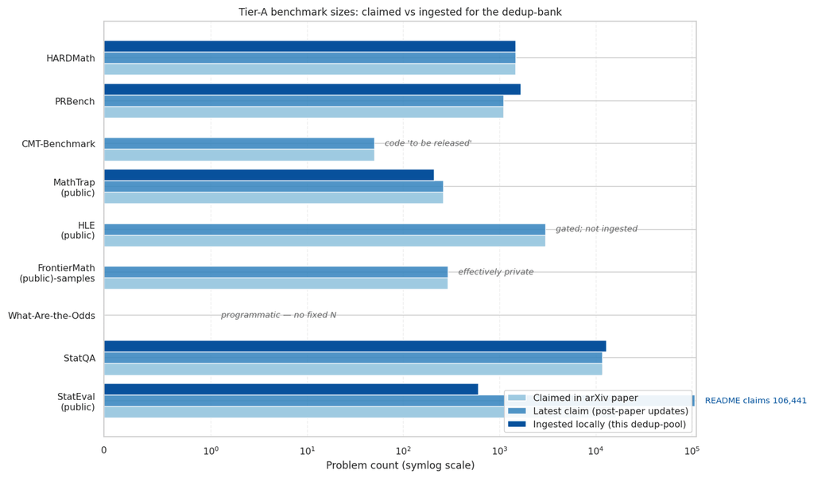

01 benchmark sizes

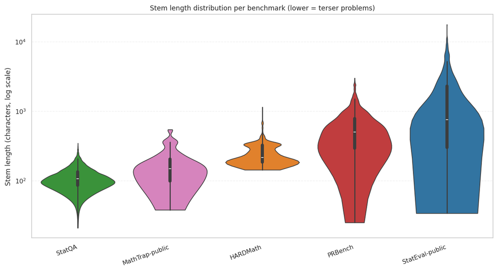

02 stem length

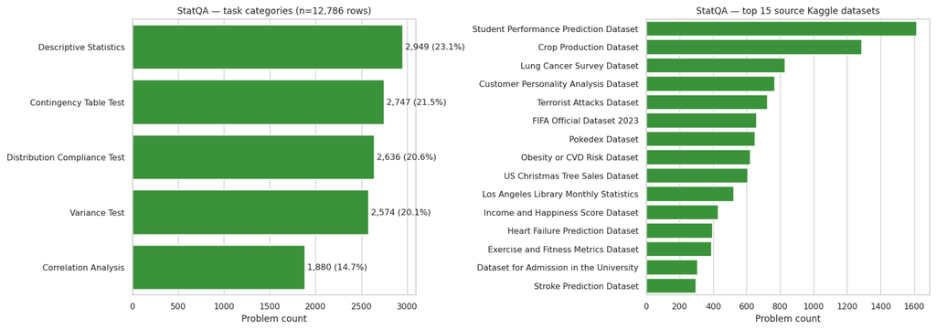

03 statqa breakdown

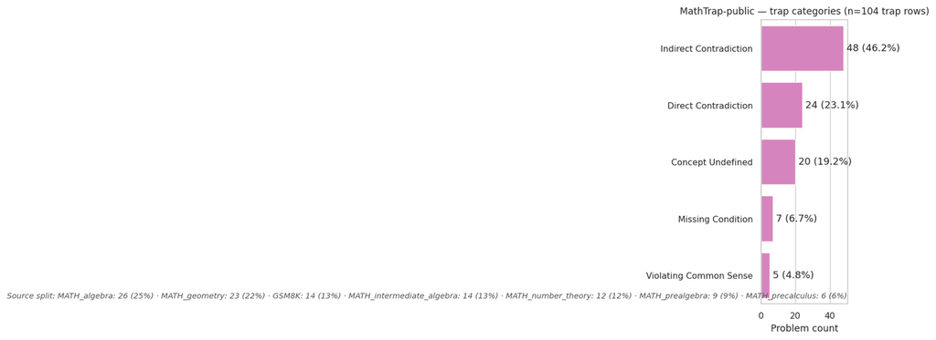

04 mathtrap traps

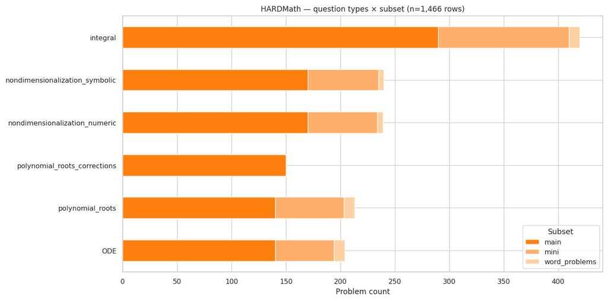

05 hardmath types

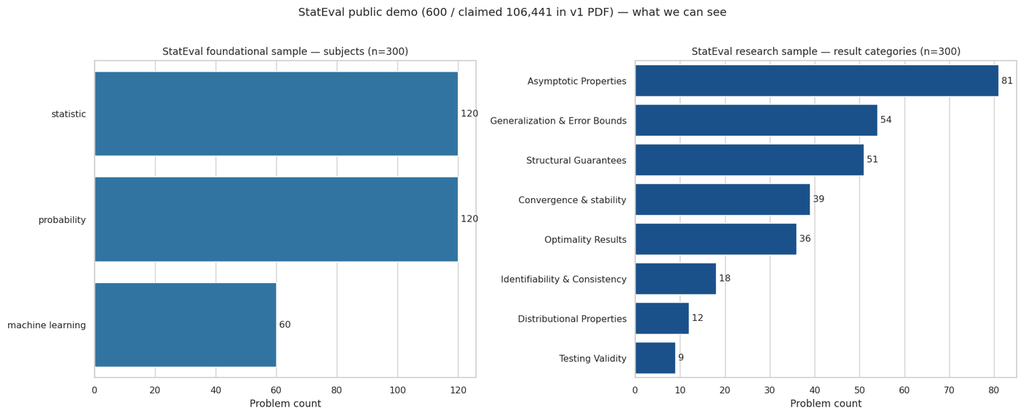

06 stateval subjects

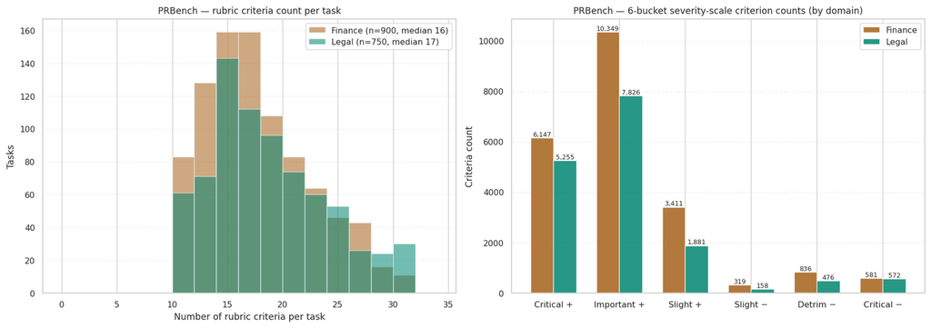

07 prbench rubric

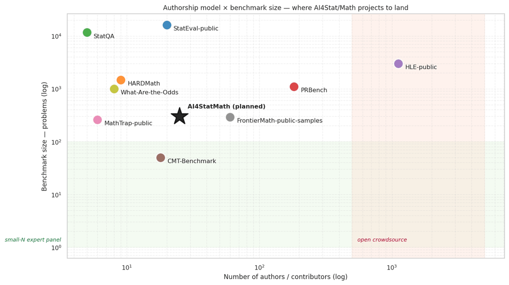

08 authorship vs size

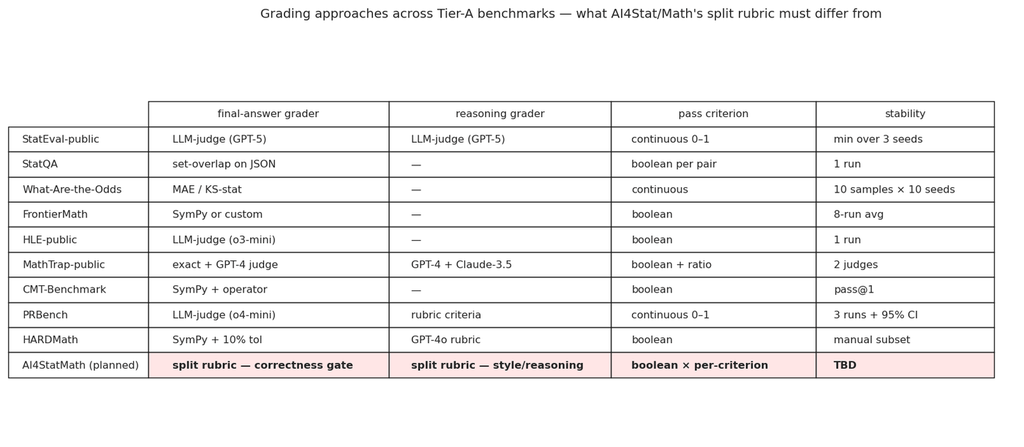

09 grading matrix

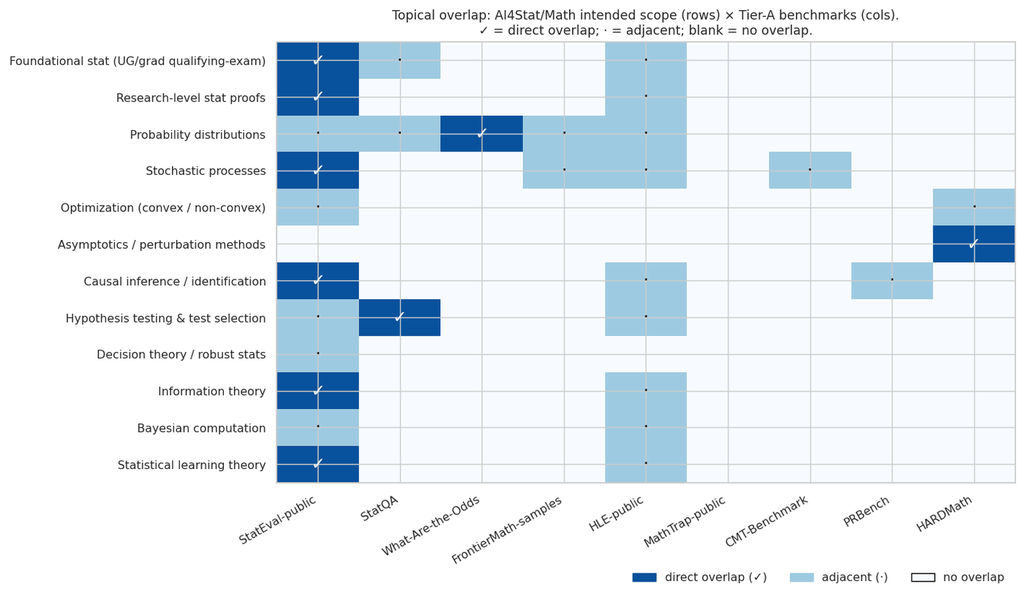

10 overlap atlas

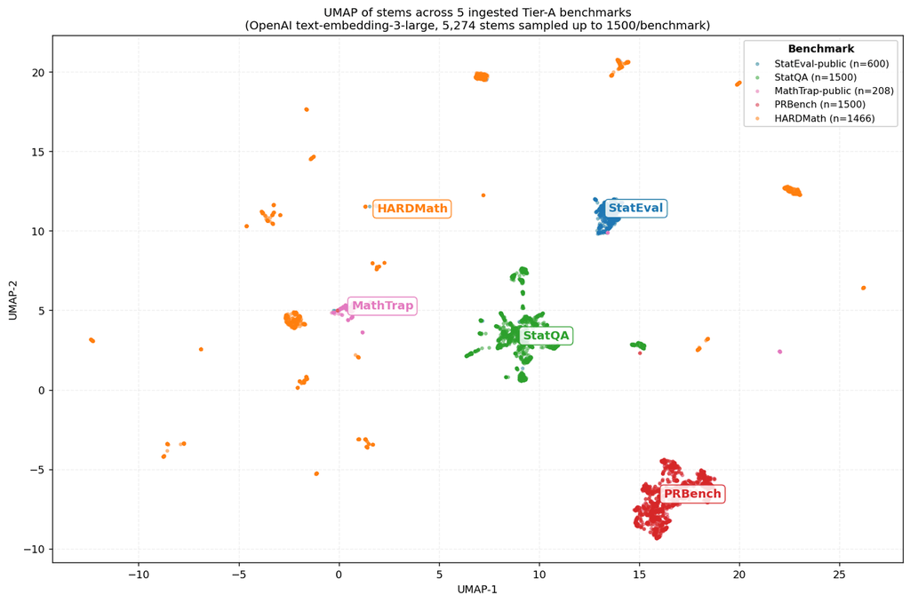

11 umap landscape

## Methodology + reproducibility

Collapsed detail. The pipeline is small and self-contained — regenerate every artifact in <2 min (excluding source-repo clones).

### Ingestion pipeline

**Show pipeline detail**

#### Narrow shared spine

```
source_benchmark · source_id · stem · dataset_public · lookup_url · ingested_at · native
```

#### Per-benchmark `native` blob preserves source vocab verbatim — no coerced cross-walk

StatEval keeps its 22 foundational subdomain labels; MathTrap its 5 trap categories; PRBench its 6-bucket scale; StatQA its CA/CTT/DCT/VT/DS families; HARDMath its question_type. Pattern overlaps go to `research/observations.md`.

```
$ python3 ingest/_metadata.py
$ python3 ingest/{mathtrap,hardmath,statqa,stateval,prbench}.py
$ python3 analyze.py            # figures 01-10
$ python3 embed_and_map.py      # figure 11 (UMAP) + NN samples
$ python3 build_html.py         # this page
```

### What's NOT in this pass

**Show caveats**

- **HLE-public** — gated; manual HF license acceptance. Catalogued only.
- **FrontierMath** — held-out private; 5 sample problems only. Structural-signature dedup.
- **CMT-Benchmark** — paper-only; code "to be released".
- **What-Are-the-Odds** — programmatic; no fixed corpus.
- **Production embedding** — UMAP, cross-benchmark NN, and the §map max-cosine table all use OpenAI `text-embedding-3-large` (3072 dimensions). The embedding shootout compared TF-IDF, `bge-small-en-v1.5`, and OpenAI; OpenAI surfaced the cleanest cross-benchmark signal (max cosine drops to 0.52 vs TF-IDF's 0.82, all UNRELATED noise). The in-browser dedup portal runs **semantic** nearest-neighbour over `bge-small-en-v1.5` embeddings of the ~5,300-stem Tier-A pool (int8-quantized + base64-baked into the HTML; the encoder loads lazily in the browser on first use), with a TF-IDF lexical fallback if the encoder fails to load. Either way, candidate text never leaves the page.

**On this page**

#### Overlap atlas

Cell gap

**Sources & citations** keep open